# hclustering_fly_human

Vera

24/02/2020

## Objectives:

In the markdown “internal_vs_external_table > internal_vs_external_fly_yeast_human_genegroups.Rmd”, I plotted Venn diagrams showing the genegroups with significant shifts between internal and external correlations (see for example internal_vs_external_table > Plots > fly_yeast_human_genegroups_internalvsexternal_significance_quadvenn.pdf). In the unfiltered quadvenn, there is a fairly big overlap between the two fly datasets and the human dataset, but not the yeast dataset (34). I wanna plot a heatmap (fly vs human) of genes annotated with genegroups in those 34 plus nearest neighbor genes in a heatmap.

## Chunk Description:

- Load packages and data (chunks 1 & 2)
- Which genegroups have significant internal vs. external shift in both fly datasets as well as in the human dataset (but not the yeast dataset)? -> vector (chunk 3)
- Modify orthologues list: add genegorup annotation (34 genegroups), keep only one fly gene per human gene and one human gene per fly gene (chunk 4)
- Normalize datasets, plot density histograms (chunk 5)
- Tidy up datasets: Add genegroup annotations (and fly gene names to human dataset) (chunks 6 & 7)
- Filter datasets for genes present in the orther dataset, get rid of duplicated genepairs in fly dataset by calculating mean (chunk 8)
- Create vector of genes of interest (genes annotated with one of the 34 genegroups plus nearest neighbors, based on fly genetic interaction correlation) (chunk 9)
- Filter datasets for genes of interest, genepairs in both datasets (chunks 10 & 11)
- Modify values (< 0 -> = 0) and spread datasets to obtain symmetrical matrices (chunks 12 & 13)
- Hierarchical clustering and heatmaps - based on fly genetic interacton profile correlation (chunks 14 - 16)
- Hierarchical clustering and heatmaps - based on human gene effect correlation (chunks 17 - 19)

## 1. Load packages

```r
library(dplyr)
library(tidyverse)
```

```r
library(ggplot2)
library(gplots)
library(heatmaply)
#library(dtplyr)
```

## 2. Load data

```r
# The table used to plot the Venn diagrams is called cor_analysis_wide in the markdown. This table is loaded here to create a vector of the 34 gene groups of interest
corr_analysis_wide <- read_delim(file = "/Users/b110/Desktop/VeraPeters/internal_vs_external_table/internal_vs_external_fly_yeast_human_genegroupsortho_wide.txt", delim = "\t")
# Annotation datasets:

# Load gene group annotations (fly), (Florian, 14.02.2020):
genegroups <- read_delim(file = "/Users/b110/Desktop/VeraPeters/internal_vs_external_table/genes_to_gene_groups.txt", delim = "\t")
# Load list of orthologue pairs from Ensembl database -27.11.2019:
orthologues <- read_delim("/Users/b110/Desktop/VeraPeters/conserved_functional_groups/new_orthologues_list_copy.txt", delim = "\t")
# Correlation datasets:

# Genetic interaction profile correlations for Fly (based on cell count), (Florian, 29.01.2020):
load(file = "/Users/b110/Desktop/VeraPeters/conserved_functional_groups/cell_count_interaction_correlations_pearson_p_unfiltered_fly.RData")
# This dataset is named GI_corrs, in the markdown mostly referred to as "cellcount"

# Morphology feature correlations for Fly, (Florian, 03.02.2020):
load(file = "/Users/b110/Desktop/VeraPeters/conserved_functional_groups/feature_correlations_pearson_p_unfiltered_fly.RData")
# This dataset is named feature_corrs

# Load human dataset (gene effect correlation)
# Load dataset filtered for genes in the orthologues list (created in chunk 4 of cons_functional_groups_human markdown)
# (otherwise, I'll have the problem of having 168 million rows again)
ceres_corrs_sep_in_ortho <- read_csv(file = "/Users/b110/Desktop/VeraPeters/conserved_functional_groups/ceres_corrs_sep_filtered.csv")
```

## 3. Which genegroups have significant internal vs. external shift in both fly datasets as well as in the human dataset (but not the yeast dataset)?

```r
# corr_analysis_wide needs to be filtered for both fly FDRs as well as human FDR to be < 0.2 and yeast FDR to be either NA or >= 0.2

# Check, if number of rows is 34 (as observed in Venn diagram):
nrow(corr_analysis_wide %>% filter(fly_fdr_GI < 0.2 & fdr_features < 0.2 & human_fdr_GI < 0.2 & (yeast_fdr_GI >= 0.2 | is.na(yeast_fdr_GI))))
```

```
## [1] 34
```

```r
# [1] 34

# Create vector of those 34 gene groups:
genegroups_34 <- (corr_analysis_wide %>%
                    filter(fly_fdr_GI < 0.2 & fdr_features < 0.2 & human_fdr_GI < 0.2 & (yeast_fdr_GI >= 0.2 | is.na(yeast_fdr_GI))))[["genegroup"]] %>%
  sort()

# Which genegroups are there?
print(genegroups_34)
```

```
##  [1] "ACTIN-RELATED PROTEIN 2/3 COMPLEX"
##  [2] "C2H2 ZINC FINGER TRANSCRIPTION FACTORS"
##  [3] "CCR4-NOT COMPLEX"
##  [4] "COAT PROTEIN COMPLEX I"
##  [5] "CONDENSIN I"
##  [6] "CYTOCHROME-C OXIDASES"
##  [7] "DYNACTIN COMPLEX"
##  [8] "EXOCYST"
##  [9] "Fibroblast Growth Factor Receptor Signaling Pathway Core Components"
## [10] "M6A METHYLTRANSFERASE COMPLEX"
## [11] "MITOCHONDRIAL COMPLEX I - NADH:UBIQUINONE OXIDOREDUCTASE COMPLEX SUBUNITS"
## [12] "MITOCHONDRIAL COMPLEX IV - CYTOCHROME C OXIDASE SUBUNITS"
## [13] "MITOCHONDRIAL F[[0]] ATP SYNTHASE COMPLEX SUBUNITS"
## [14] "MITOCHONDRIAL F[[1]] ATP SYNTHASE COMPLEX SUBUNITS"
## [15] "MITOCHONDRIAL SMALL RIBOSOMAL PROTEINS"
```

[output cut: 19 more lines]

```r
# [1] "ACTIN-RELATED PROTEIN 2/3 COMPLEX"
# [2] "C2H2 ZINC FINGER TRANSCRIPTION FACTORS"
# [3] "CCR4-NOT COMPLEX"
# [4] "COAT PROTEIN COMPLEX I"
# [5] "CONDENSIN I"
# [6] "CYTOCHROME-C OXIDASES"
# [7] "DYNACTIN COMPLEX"
# [8] "EXOCYST"
# [9] "Fibroblast Growth Factor Receptor Signaling Pathway Core Components"
#[10] "M6A METHYLTRANSFERASE COMPLEX"
#[11] "MITOCHONDRIAL COMPLEX I - NADH:UBIQUINONE OXIDOREDUCTASE COMPLEX SUBUNITS"
#[12] "MITOCHONDRIAL COMPLEX IV - CYTOCHROME C OXIDASE SUBUNITS"
#[13] "MITOCHONDRIAL F[[0]] ATP SYNTHASE COMPLEX SUBUNITS"
#[14] "MITOCHONDRIAL F[[1]] ATP SYNTHASE COMPLEX SUBUNITS"
#[15] "MITOCHONDRIAL SMALL RIBOSOMAL PROTEINS"
#[16] "NADH DEHYDROGENASES"
#[17] "Negative Regulators of Insulin-like Receptor Signaling Pathway"
#[18] "Negative Regulators of JAK-STAT Signaling Pathway"
#[19] "Negative Regulators of Torso Signaling Pathway"
#[20] "NEUROPEPTIDES"
#[21] "NK-LIKE HOMEOBOX TRANSCRIPTION FACTORS"
#[22] "NUCLEOSOME REMODELING DEACETYLASE COMPLEX"
#[23] "Platelet-Derived Growth Factor-Vascular Endothelial Growth Factor Receptor-Related Signaling Pathway Core Components"
#[24] "POLYADENYLATION FACTORS"
#[25] "RAB GTPASES"
#[26] "RNA EXOSOME COMPLEX"
#[27] "S1A SERINE PROTEASES - CHYMOTRYPSIN-LIKE"
#[28] "SLC22 FAMILY OF ORGANIC IONS TRANSPORTERS"
#[29] "STRIATIN-INTERACTING PHOSPHATASE AND KINASE COMPLEX"
#[30] "TRANSCRIPTION EXPORT COMPLEX"
#[31] "TRAPP COMPLEX"
#[32] "VACUOLAR ATPASE V1 DOMAIN SUBUNITS"
#[33] "WASP AND SCAR HOMOLOG COMPLEX"
#[34] "WAVE REGULATORY COMPLEX"

# Create vector of genes annotated with one of those 34 genegroups:
genes_genegroups_34 <- (genegroups %>% filter(gene_group %in% genegroups_34))[["current_symbol"]] %>% unique() %>% sort()
```

## 4. Add genegroup annotation (filtered) to orthologues list, create unique orthologues (one human gene per fly gene and vice versa)

```r
# Add genegroup annotation (filtered) to orthologues list
orthologues_genegroups <- left_join(orthologues, (genegroups %>%
                                                    rename(Gene_stable_ID = current_fbgn) %>%
                                                    filter(gene_group %in% genegroups_34)), by = "Gene_stable_ID") %>%
                          select(-S_cerevisiae_gene_name,                                            # Columns corresponding to S. cerevisiae can be dropped
                                  -S_cerevisiae_orthology_confidence_0low_1high,
                                  -S_cerevisiae_gene_stable_ID,
                                  -percentage_id_query_gene_identical_to_target_S_cerevisiae_gene) %>%
                          distinct()                                                                  # Remove duplicated rows
dim(orthologues_genegroups)
```

```
## [1] 31632     8
```

```r
# [1] 31632     8

# How many rows have genegroup annotations?
nrow(orthologues_genegroups %>% select(gene_group) %>% drop_na())
```

```
## [1] 2515
```

```r
# [1] 2515 -> the majority of the genes is not annotated (at least not with one of the 34 genegroups)
# Make sure that there are 34 different annotations:
nrow(orthologues_genegroups %>% select(gene_group) %>% drop_na() %>% distinct())
```

```
## [1] 34
```

```r
# [1] 34

# Create unique orthologues_genegroups list: one human gene corresponds to only one fly gene and one fly gene to only one human gene
orthologues_genegroups_unique <- orthologues_genegroups %>%
  group_by(Human_gene_name) %>%                                               # First: one fly gene per human gene
  arrange(desc(percentage_id_query_gene_identical_to_target_Human_gene)) %>%
  do(head(.,1)) %>%
  ungroup() %>%
  group_by(Gene_name) %>%                                                     # Second: one human gene per fly gene
  arrange(desc(percentage_id_query_gene_identical_to_target_Human_gene)) %>%
  do(head(.,1)) %>%
  ungroup()
dim(orthologues_genegroups_unique)
```

```
## [1] 5380    8
```

```r
# [1] 5380    8
nrow(orthologues_genegroups_unique %>% select(gene_group) %>% drop_na() %>% distinct())
```

```
## [1] 32
```

```r
# [1] 32 - two of the genegroups got lost
```

## 5. Normalize datasets, plot density histograms

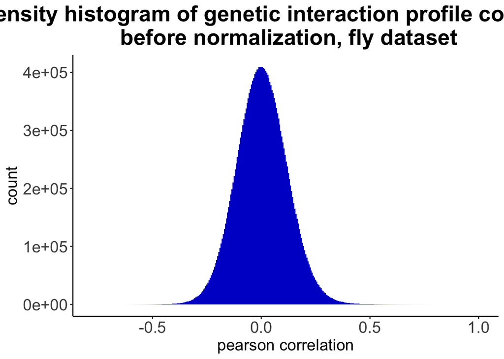

```r
# Define b110 theme:
theme_b110<-function(){
  theme_classic() +
  theme(
    axis.text=element_text(size = 16),
    axis.title=element_text(size = 16),
    plot.title = element_text(size = 22,hjust = 0.5,face="bold"),
    legend.title = element_text(size = 22),
    legend.text = element_text(size =16),
    legend.position = "bottom"
    )
}

# Density histograms:
# Before normalization: fly genetic interaction profile correlation
GI_corrs %>%
  ggplot(aes(x = r)) +
  geom_histogram(binwidth = 0.005, fill = "blue3") +
  theme_b110() +
  xlab("pearson correlation") +
  ggtitle(" Density histogram of genetic interaction profile correlation \n before normalization, fly dataset")
```

```r
min(GI_corrs$r)
```

```
## [1] -0.7740765
```

```r
# [1] -0.7740765
max(GI_corrs$r)
```

```
## [1] 1
```

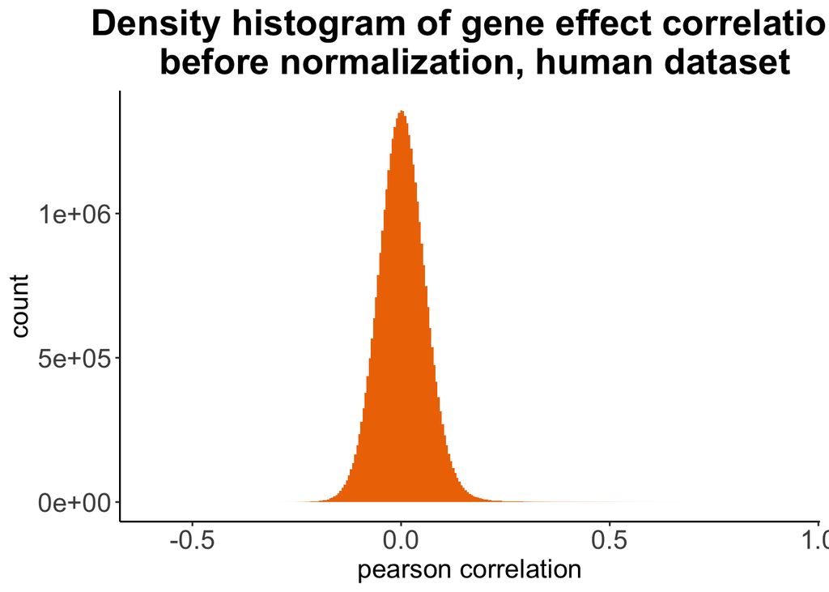

```r
# [1] 1

# Before normalization: human gene effect correlation
ceres_corrs_sep_in_ortho %>%
  ggplot(aes(x = r)) +
  geom_histogram(binwidth = 0.005, fill = "darkorange2") +
  theme_b110() +
  xlab("pearson correlation") +
  ggtitle(" Density histogram of gene effect correlation \n before normalization, human dataset")
```

```r
min(ceres_corrs_sep_in_ortho$r)
```

```
## [1] -0.5949766
```

```r
# [1] -0.5949766
max(ceres_corrs_sep_in_ortho$r)
```

```
## [1] 0.9258851
```

```r
# [1] 0.9258851

# The distributions are not similar -> normalization needed by dividing by standard deviation and by overall maximum normalized value
# Which value is the overall maximum r_norm value?
max((GI_corrs %>%  mutate(r_norm = r/sd(r)))$r_norm)
```

```
## [1] 8.529139
```

```r
# [1] 8.529139
max((ceres_corrs_sep_in_ortho %>%  mutate(r_norm = r/sd(r)))$r_norm)
```

```
## [1] 16.00281
```

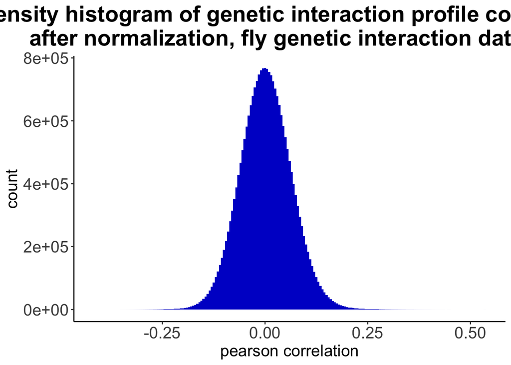

```r
# [1] 16.00281

#### Normalization ####

# fly genetic interaction correlations:
GI_corrs_norm <- GI_corrs %>%
  mutate(r_norm = r/sd(r)) %>%        # divide all r values by their standard deviation
  mutate(r_norm = r_norm/16.00281)    # divide normalized r values by overall maximum r value

# human gene effect correlations:
ceres_corrs_sep_in_ortho_norm <- ceres_corrs_sep_in_ortho %>%
  mutate(r_norm = r/sd(r)) %>%        # divide all r values by their standard deviation
  mutate(r_norm = r_norm/16.00281)    # divide normalized r values by overall maximum r value

# Density histograms
# After normalization: fly genetic interaction profile correlation
GI_corrs_norm %>%
  ggplot(aes(x = r_norm)) +
  geom_histogram(binwidth = 0.005, fill = "blue3") +
  theme_b110() +
  xlab("pearson correlation") +
  ggtitle(" Density histogram of genetic interaction profile correlation \n after normalization, fly genetic interaction dataset")
```

```r
min(GI_corrs_norm$r_norm)
```

```
## [1] -0.4125654
```

```r
# [1] -0.4125654
max(GI_corrs_norm$r_norm)
```

```
## [1] 0.5329776
```

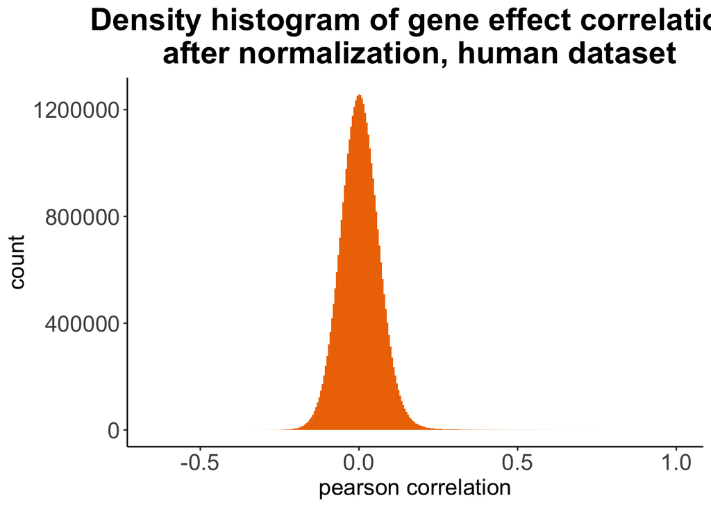

```r
# [1] 0.5329776

# After normalization: human gene effect correlation
ceres_corrs_sep_in_ortho_norm %>%
  ggplot(aes(x = r_norm)) +
  geom_histogram(binwidth = 0.005, fill = "darkorange2") +
  theme_b110() +
  xlab("pearson correlation") +
  ggtitle(" Density histogram of gene effect correlation \n after normalization, human dataset")
```

```r
min(ceres_corrs_sep_in_ortho_norm$r_norm)
```

```
## [1] -0.6426032
```

```r
# [1] -0.6426032
max(ceres_corrs_sep_in_ortho_norm$r_norm)
```

```
## [1] 1
```

```r
# [1] 1
```

## 6. Tidy up fly datasets

```r
# Use Florian's code to separate gene and IDs into single columns:
# For cell count-based data:
fly_correlation_cellcount <- GI_corrs_norm %>%
  separate(x,c("genex","idx"),sep = "öö")%>%
  separate(y,c("geney","idy"),sep = "öö") %>%
  dplyr::select(genex,geney,idx,idy,r, r_norm)
dim(fly_correlation_cellcount)
```

```
## [1] 23526370        6
```

```r
# [1] 23526370        6
# For feature-based data:
#fly_correlation_features <- feature_corrs %>%
#  separate(x,c("genex","idx"),sep = "öö")%>%
#  separate(y,c("geney","idy"),sep = "öö") %>%
#  dplyr::select(genex,geney,idx,idy,r)
#dim(fly_correlation_features)
# [1] 23526370        5

# Create new columns in both datasets (genegroup_1 and genegroup_2), by left-joining with the orthologues_genegroups list
# Cell count-based data:
fly_corr_cellcount_anno <- fly_correlation_cellcount %>%
  rename(Gene_name = genex) %>%
  left_join((orthologues_genegroups_unique %>% select(Gene_name, gene_group) %>% distinct()), by = "Gene_name") %>%
  rename(Gene_1 = Gene_name, genegroup_1 = gene_group) %>%
  rename(Gene_name = geney) %>%
  left_join((orthologues_genegroups_unique %>% select(Gene_name, gene_group) %>% distinct()), by = "Gene_name") %>%
  rename(Gene_2 = Gene_name, genegroup_2 = gene_group)
dim(fly_corr_cellcount_anno)
```

```
## [1] 23526370        8
```

```r
# [1] 23526370        8

# Feature-based data:
#fly_corr_features_anno <- fly_correlation_features %>%
#  rename(Gene_name = genex) %>%
#  left_join((orthologues_genegroups_unique %>% select(Gene_name, gene_group) %>% distinct()), by = "Gene_name") %>%
#  rename(Gene_1 = Gene_name, genegroup_1 = gene_group) %>%
#  rename(Gene_name = geney) %>%
#  left_join((orthologues_genegroups_unique %>% select(Gene_name, gene_group) %>% distinct()), by = "Gene_name") %>%
#  rename(Gene_2 = Gene_name, genegroup_2 = gene_group)
#dim(fly_corr_features_anno)
# [1] 23526370        7
```

## 7. Tidy up human dataset

```r
# The human dataset was already filtered to contain only genes present in the unmodified orthologues list (see cons_functional_groups_human markdown) (otherwise, genegroup annotation not possible)

dim(ceres_corrs_sep_in_ortho)
```

```
## [1] 37208251        5
```

```r
# [1] 37208251        5

# Add fly gene names and genegroup annotations to human dataset:
human_corr_anno <- ceres_corrs_sep_in_ortho_norm %>%
  select(-xnum, -ynum) %>%
  rename(Human_gene_name = x) %>%
  left_join((orthologues_genegroups_unique %>% select(Human_gene_name, Gene_name, gene_group) %>% distinct()), by = "Human_gene_name") %>%
  rename(Gene_1 = Human_gene_name,Gene_1_flyname = Gene_name, genegroup_1 = gene_group) %>%
  rename(Human_gene_name = y) %>%
  left_join((orthologues_genegroups_unique %>% select(Human_gene_name, Gene_name, gene_group) %>% distinct()), by = "Human_gene_name") %>%
  rename(Gene_2 = Human_gene_name, Gene_2_flyname = Gene_name, genegroup_2 = gene_group) %>%
  filter(! (is.na(Gene_1_flyname) | is.na(Gene_2_flyname)))   # keep only rows, which have a corresponding fly gene name (mandatory for plotting later)
dim(human_corr_anno)
```

```
## [1] 13320541        8
```

```r
# [1] 13320541        8
```

## 8. Filter datasets for genes present in the other datasets (gene pairs present in all datasets)

```r
# Create vectors of genes present in both columns of fly dataset/human dataset
# Fly:
fly_genes_1 <- (fly_corr_cellcount_anno %>% select(Gene_1) %>% distinct())[["Gene_1"]]
fly_genes_2 <- (fly_corr_cellcount_anno %>% select(Gene_2) %>% distinct())[["Gene_2"]]
fly_genes <- subset(fly_genes_1, fly_genes_1 %in% fly_genes_2) %>% unique() %>% sort()
rm(fly_genes_1, fly_genes_2)

# Human (vector containing fly gene names present in human dataset as human gene names)
human_genes_1 <- (human_corr_anno %>% select(Gene_1_flyname) %>% distinct())[["Gene_1_flyname"]]
human_genes_2 <- (human_corr_anno %>% select(Gene_2_flyname) %>% distinct())[["Gene_2_flyname"]]
human_genes <- subset(human_genes_1, human_genes_1 %in% human_genes_2) %>% unique() %>% sort()
rm(human_genes_1, human_genes_2)

# Filter fly datasets: both Genes have to be in human_genes vector
fly_corr_cellcount_anno_filtered <- fly_corr_cellcount_anno %>%
  filter(Gene_1 %in% human_genes & Gene_2 %in% human_genes)
dim(fly_corr_cellcount_anno_filtered)
```

```
## [1] 4128501       8
```

```r
# [1] 4128501       8
#fly_corr_features_anno_filtered <- fly_corr_features_anno %>%
#  filter(Gene_1 %in% human_genes & Gene_2 %in% human_genes)
#dim(fly_corr_features_anno_filtered)
# [1] 4128501       7

# Filter human dataset: both Genes (fly names) have to be in fly_genes vector
human_corr_anno_filtered <- human_corr_anno %>%
  filter(Gene_1_flyname %in% fly_genes & Gene_2_flyname %in% fly_genes)
dim(human_corr_anno_filtered)
```

```
## [1] 4094091       8
```

```r
# [1] 4094091       7

# There are duplications in the fly datasets (same gene 1 and gene 2, but more than one correlation value (and also different ids)):
nrow(fly_corr_cellcount_anno_filtered)
```

```
## [1] 4128501
```

```r
# [1] 4128501
nrow(fly_corr_cellcount_anno_filtered %>% select(Gene_1, Gene_2) %>% distinct())
```

```
## [1] 4088383
```

```r
# [1] 4088383

# In the human dataset, this is not the case:
#nrow(human_corr_anno_filtered_genepairs)
nrow(human_corr_anno_filtered)
```

```
## [1] 4094091
```

```r
# [1] 4094091
#nrow(human_corr_anno_filtered_genepairs %>% select(genepair) %>% distinct())
nrow(human_corr_anno_filtered %>% select(Gene_1_flyname, Gene_2_flyname) %>% distinct())
```

```
## [1] 4094091
```

```r
# [1] 4094091

# Get rid of duplicated gene pairs in fly datasets by calculating mean of r
fly_corr_cellcount_anno_filtered_mean <- fly_corr_cellcount_anno_filtered %>%
  group_by(Gene_1, Gene_2) %>%        # mean is calculated per gene pair
  mutate(r_mean = mean(r_norm)) %>%   # calculate mean in new column
  select(-r, -r_norm, -idx, -idy) %>% # drop original mean column and ids (otherwise, there will still be duplicates after distinct())
  distinct()                          # get rid of duplicated rows
dim(fly_corr_cellcount_anno_filtered_mean)
```

```
## [1] 4088383       5
```

```r
# [1] 4088383       5
#fly_corr_features_anno_filtered_mean <- fly_corr_features_anno_filtered %>%
#  group_by(Gene_1, Gene_2) %>%        # mean is calculated per gene pair
#  mutate(r_mean = mean(r)) %>%        # calculate mean in new column
#  select(-r, -idx, -idy) %>%          # drop original mean column and ids (otherwise, there will still be duplicates after distinct())
#  distinct()                          # get rid of duplicated rows
#dim(fly_corr_features_anno_filtered_mean)
# [1] 4088383       5
```

## 9. Create vector of genes of interest (genes annotated with one of the 34 genegroups plus nearest neighbors, based on fly genetic interaction correlation)

```r
# Filtering is supposed to be based on the fly genetic interaction profile correlation data, so I'll continue with the cellcount dataset to create a vector of genes of interest

# I wanna keep
# 1. all the genes which have a genegroup annotation out of the 34
# -> For this, I can just use the genes_genegroups_34 vector

# 2. For each genegroup, I wanna keep the "nearest not-annotated neighbor", meaning the gene (pair) with the highest correlation, for gene pairs in which only one gene is annotated
# -> This is what I'm trying now:
# keep only rows, in which only one gene has a genegroup annotation

fly_corr_cellcount_anno_filtered_oneanno <- fly_corr_cellcount_anno_filtered_mean %>%
  filter((is.na(genegroup_1) | is.na(genegroup_2)) & !(is.na(genegroup_1) & is.na(genegroup_2)))
dim(fly_corr_cellcount_anno_filtered_oneanno)
```

```
## [1] 628800      5
```

```r
# [1] 628800      5

# Now, I wanna have a for-loop looking like this:

# for each annotated gene (filtered already in step above)
#       filter: Gene_1 == i | Gene_2 == i
#       arrange by desc correlation value
#       get highest correlation value (use do head (.1))
#       write gene pair (or whole row) into new dataframe/list
# using: genes_genegroups_34 vector

# Create empty list to add rows (resulting from for loop)
#nearest_neighbors_list <- list()

# for loop:
# Filter dataset for Gene_1 OR Gene_2 being member of genes_genegroups_34 list, arrange r correlation values (descending), take top row (highest correlation value), write this row in nearest_neighbors_list

#pb = txtProgressBar(min = 0, max = length(genes_genegroups_34), initial = 0, style=3) # style=3 -> progress bar with %values

#fly_corr_cellcount_anno_filtered_oneanno_lazy <- lazy_dt(fly_corr_cellcount_anno_filtered_oneanno)

#for (i in 1:length(genes_genegroups_34)) {
#  nearest_neighbors_list[[i]] <- (fly_corr_cellcount_anno_filtered_oneanno_lazy %>%
#      filter((Gene_1 == genes_genegroups_34[i] | Gene_2 == genes_genegroups_34[i])) %>%
#      arrange(desc(r_mean)) %>%
#      as_tibble() %>%
#      do(head(.,1)))
#  setTxtProgressBar(pb,i)
#}

# Convert list to dataframe
#nearest_neighbors_df <- do.call("rbind", nearest_neighbors_list)
#dim(nearest_neighbors_df)
# [1] 240   5
#rm(nearest_neighbors_list)

# Save nearest neighbors dataframe:
#write_delim(nearest_neighbors_df, path = "/Users/b110/Desktop/VeraPeters/hclustering_cross_organism/hclustering_fly_human_nearest_neighbors.txt", delim = "\t")

# Load nearest neighbors dataframe:
nearest_neighbors_df <- read_delim(file = "/Users/b110/Desktop/VeraPeters/hclustering_cross_organism/hclustering_fly_human_nearest_neighbors.txt", delim = "\t")
# Create vector of genes in the nearest neighbors df:
nearest_neighbors_genes <- c(nearest_neighbors_df[["Gene_1"]], nearest_neighbors_df[["Gene_2"]]) %>% unique() %>% sort()
length(nearest_neighbors_genes)
```

```
## [1] 434
```

```r
# [1] 434 (contains also annotated genes - remove those:)
nearest_neighbors_genes <- subset(nearest_neighbors_genes, ! nearest_neighbors_genes %in% genes_genegroups_34)
length(nearest_neighbors_genes)
```

```
## [1] 194
```

```r
# [1] 194 -> 194 non-annotated genes (nearest neighbors)

# Create vector of genes of interest by combining genes_genegroups_34 vector and nearest_neighbors_genes:
genes_of_interest <- c(genes_genegroups_34, nearest_neighbors_genes) %>% sort()
length(genes_of_interest)
```

```
## [1] 987
```

```r
# [1] 987
```

## 10. Filter datasets for genes of interest

```r
# Filter fly datasets for genes of interest:
fly_corr_cellcount_genesofinterest <- fly_corr_cellcount_anno_filtered_mean %>%
  filter(Gene_1 %in% genes_of_interest & Gene_2 %in% genes_of_interest)
dim(fly_corr_cellcount_genesofinterest)
```

```
## [1] 93963     5
```

```r
# [1] 93963     5
#fly_corr_features_genesofinterest <- fly_corr_features_anno_filtered_mean %>%
#  filter(Gene_1 %in% genes_of_interest & Gene_2 %in% genes_of_interest)
#dim(fly_corr_features_genesofinterest)
# [1] 93963     5

# Filter human dataset for genes of interest:
human_corr_genesofinterest <- human_corr_anno_filtered %>%
  filter(Gene_1_flyname %in% genes_of_interest & Gene_2_flyname %in% genes_of_interest)
dim(human_corr_genesofinterest)
```

```
## [1] 93961     8
```

```r
# [1] 93961     7
```

## 11. Make sure, that genes are present in both datasets and genepairs are the same in all datasets

```r
# Make sure, that genes are present in both columns (mandatory for matrix to be symmetrical):

# Fly datasets:
# Vectors:
fly_gene_1 <- fly_corr_cellcount_genesofinterest[["Gene_1"]] %>% unique()
fly_gene_2 <- fly_corr_cellcount_genesofinterest[["Gene_2"]] %>% unique()

# Filter fly datasets:
fly_corr_cellcount_genesofinterest_filtered <- fly_corr_cellcount_genesofinterest %>%
  filter(Gene_1 %in% fly_gene_2) %>%
  filter(Gene_2 %in% fly_gene_1)
dim(fly_corr_cellcount_genesofinterest_filtered)
```

```
## [1] 93098     5
```

```r
# [1] 93098     5
#fly_corr_features_genesofinterest_filtered <- fly_corr_features_genesofinterest %>%
#  filter(Gene_1 %in% fly_gene_2) %>%
#  filter(Gene_2 %in% fly_gene_1)
#dim(fly_corr_features_genesofinterest_filtered)
# # [1] 93098     5

# Human dataset:
# Vectors:
human_flygene_1 <- human_corr_genesofinterest[["Gene_1_flyname"]] %>%  unique()
human_flygene_2 <- human_corr_genesofinterest[["Gene_2_flyname"]] %>%  unique()

# Filter human dataset:
human_corr_genesofinterest_filtered <- human_corr_genesofinterest %>%
  filter(Gene_1_flyname %in% human_flygene_2) %>%
  filter(Gene_2_flyname %in% human_flygene_1)
dim(human_corr_genesofinterest_filtered)
```

```
## [1] 93096     8
```

```r
# [1] 93096     7

#### genepairs ####

# Create vector of genepairs in fly dataset:
fly_genepairs_genesofinterest <- (fly_corr_cellcount_genesofinterest_filtered %>% unite(Gene_1, Gene_2, col = "genepair", sep = "öö") %>% select(genepair) %>% distinct())[["genepair"]]

# Create duplicated dataset of human dataset (with Gene_1/Gene_2, Gene_1_flyname/Gene_2_flyname, genegroup_1/genegroup_2 switched)
human_corr_genesofinterest_filtered_switched <- human_corr_genesofinterest_filtered %>%
  rename(Gene_2 = Gene_1, Gene_1 = Gene_2, Gene_2_flyname = Gene_1_flyname, Gene_1_flyname = Gene_2_flyname, genegroup_2 = genegroup_1, genegroup_1 = genegroup_2)
human_corr_genesofinterest_filtered_duplicates <- rbind(human_corr_genesofinterest_filtered, human_corr_genesofinterest_filtered_switched)
dim(human_corr_genesofinterest_filtered_duplicates)
```

```
## [1] 186192      8
```

```r
# [1] 186192      7 (186192/2 = 93096)

# Filter human duplicated dataset for gene pairs in fly datasets:
human_corr_anno_genepairs_flydataset <- human_corr_genesofinterest_filtered_duplicates %>%
  unite(Gene_1_flyname, Gene_2_flyname, col = "genepair", sep = "öö") %>%
  filter(genepair %in% fly_genepairs_genesofinterest) %>%
  distinct()
dim(human_corr_anno_genepairs_flydataset)
```

```
## [1] 92235     7
```

```r
# [1] 92235     6

# Create vector of genepairs in already filtered human dataset:
human_genepairs_genesofinterest <- (human_corr_anno_genepairs_flydataset %>% select(genepair) %>% distinct())[["genepair"]]

# Create duplicated dataset of fly dataset (with Gene_1/Gene_2, genegroup_1/genegroup_2 switched)
fly_corr_cellcount_genesofinterest_filtered_switched <- fly_corr_cellcount_genesofinterest_filtered %>%
  rename(Gene_2 = Gene_1, Gene_1 = Gene_2, genegroup_2 = genegroup_1, genegroup_1 = genegroup_2)
fly_corr_cellcount_genesofinterest_filtered_duplicates <- rbind(fly_corr_cellcount_genesofinterest_filtered, fly_corr_cellcount_genesofinterest_filtered_switched)
dim(fly_corr_cellcount_genesofinterest_filtered_duplicates)
```

```
## [1] 186196      5
```

```r
#[1] 186196      5 (186196/2 = 93098)

# Filter fly duplicated dataset for gene pairs in human dataset:
fly_corr_cellcount_anno_genepairs_humandataset <- fly_corr_cellcount_genesofinterest_filtered_duplicates %>%
  unite(Gene_1, Gene_2, col = "genepair", sep = "öö") %>%
  filter(genepair %in% human_genepairs_genesofinterest) %>%
  distinct()
dim(fly_corr_cellcount_anno_genepairs_humandataset)
```

```
## [1] 92235     4
```

```r
# [1] 92235     4

# Make sure, that gene airs in the different datasets are the same:
identical((fly_corr_cellcount_anno_genepairs_humandataset[["genepair"]] %>% sort()), (human_corr_anno_genepairs_flydataset[["genepair"]] %>% sort()))
```

```
## [1] TRUE
```

```r
# [1] TRUE

# Now, we have two datasets (fly genetic interaction correlationa and human correlation), which have the same gene pairs and can be used to spread to matrix
```

## 12. Spread dataset to symmetrical matrix - fly genetic interactions

```r
# Set all values < 0 -> = 0 and calculate *(-1)
fly_corr_cellcount_anno_genepairs_humandataset <- fly_corr_cellcount_anno_genepairs_humandataset %>%
  mutate(r_mean = ifelse(r_mean < 0, 0, r_mean)) %>%
  mutate(r_mean = -1*r_mean)

# Duplicate dataset (to get symmetrical matrix)
fly_corr_cellcount_anno_genepairs_humandataset_new <- (rbind((fly_corr_cellcount_anno_genepairs_humandataset %>%
                                                               separate(genepair, into = c("Gene_1", "Gene_2"), sep = "öö")),
                                                             (fly_corr_cellcount_anno_genepairs_humandataset %>%
                                                                separate(genepair, into = c("Gene_1", "Gene_2"), sep = "öö") %>%
                                                                rename(Gene_2 = Gene_1, Gene_1 = Gene_2))))

# Spread matrix
fly_cellcount_spreaded <- fly_corr_cellcount_anno_genepairs_humandataset_new %>%
  select(-genegroup_1, -genegroup_2) %>%
  spread(Gene_2, r_mean) %>%
  arrange(Gene_1) %>%
  column_to_rownames("Gene_1")
dim(fly_cellcount_spreaded)
```

```
## [1] 430 430
```

```r
# [1] 430 430

# Symmetrical?
identical(rownames(fly_cellcount_spreaded), colnames(fly_cellcount_spreaded))
```

```
## [1] TRUE
```

```r
# [1] TRUE
```

## 13. Spread dataset to symmetrical matrix - human dataset

```r
# Set all values < 0 -> = 0
human_corr_anno_genepairs_flydataset <- human_corr_anno_genepairs_flydataset %>%
  mutate(r_norm = ifelse(r_norm < 0, 0, r_norm))

# Duplicate dataset (to get symmetrical matrix later)
human_corr_anno_genepairs_flydataset_new <- (rbind((human_corr_anno_genepairs_flydataset %>%
                                                      separate(genepair, into = c("Gene_1_flyname", "Gene_2_flyname"), sep = "öö")),
                                                   (human_corr_anno_genepairs_flydataset %>%
                                                      separate(genepair, into = c("Gene_1_flyname", "Gene_2_flyname"), sep = "öö") %>%
                                                      rename(Gene_2_flyname = Gene_1_flyname, Gene_1_flyname = Gene_2_flyname))))

# Spread matrix
human_spreaded <- human_corr_anno_genepairs_flydataset_new %>%
  select(-genegroup_1, -genegroup_2, -Gene_1, -Gene_2, -r) %>%
  spread(Gene_2_flyname, r_norm) %>%
  arrange(Gene_1_flyname) %>%
  column_to_rownames("Gene_1_flyname")
dim(human_spreaded)
```

```
## [1] 430 430
```

```r
# [1] 430 430

# Symmetrical?
identical(rownames(human_spreaded), colnames(human_spreaded))
```

```
## [1] TRUE
```

```r
# [1] TRUE

# Make sure that matrices of the two datasets have the same row/colnames:
identical(rownames(fly_cellcount_spreaded), rownames(human_spreaded))
```

```
## [1] TRUE
```

```r
identical(colnames(fly_cellcount_spreaded), colnames(human_spreaded))
```

```
## [1] TRUE
```

```r
# Both return TRUE
```

## 14. Hierarchical clustering - based on genetic interaction profile correlation (fly)

```r
# Create hierarchical clustering vector, based on genetic interaction profile correlations:
distance_fly_cellcount <- dist(fly_cellcount_spreaded)
ordered_fly_cellcount <- hclust(distance_fly_cellcount)$order
# Ordered_fly_cellcount is a vector containing the order of hierarchical clustered columns/rows based on the original matrix and can be used to order both symmetrical matrices according to clusters generated for the genetic interaction profile (fly) correlation values

# Clustered matrix for fly cellcount:
fly_cellcount_ordered <- fly_cellcount_spreaded[ordered_fly_cellcount, ordered_fly_cellcount]

# Clustered matrix for human:
human_clust_fly_cellcount <- human_spreaded[ordered_fly_cellcount, ordered_fly_cellcount]

# Make sure that both matrices are ordered the same way:
identical(rownames(fly_cellcount_ordered), rownames(human_clust_fly_cellcount))
```

```
## [1] TRUE
```

```r
identical(colnames(fly_cellcount_ordered), colnames(human_clust_fly_cellcount))
```

```
## [1] TRUE
```

```r
# both return TRUE

# Generate common clustered matrix of both clustered matrices:
common_matrix_clustered_fly_cellcount <- fly_cellcount_ordered
common_matrix_clustered_fly_cellcount[upper.tri(common_matrix_clustered_fly_cellcount)] <- human_clust_fly_cellcount[upper.tri(human_clust_fly_cellcount)]
```

## 15. Heatmap of hierarchical clustered matrix (clustering based on fly genetic interaction profile correlation)

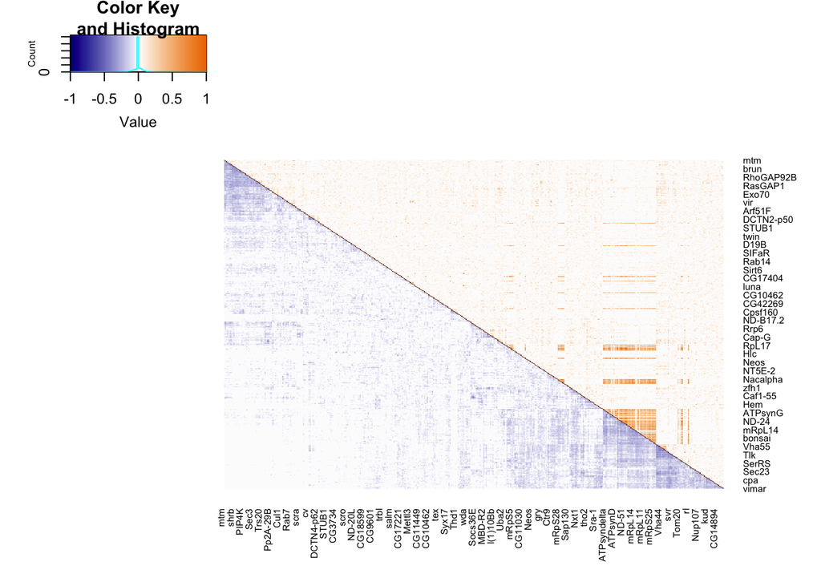

```r
common_matrix_clustered_fly_cellcount_matrix <- data.matrix(common_matrix_clustered_fly_cellcount)

heatmap.2(common_matrix_clustered_fly_cellcount_matrix,
          Rowv = FALSE,
          Colv = FALSE,
          col = c((colorRampPalette(c("darkblue", "white", "darkorange2"))(100))),
          trace = "none",
          dendrogram = "none",
          na.color = "darkorange4")
```

## 16. Interactive heatmap of hierarchical clustered matrix (clustering based on fly gen. int. profile correlation), including genegroup annotations

```r
# Replace NA values by -1.01 (to make diagonal be plotted in dark blue, instead of white)
common_matrix_clustered_fly_cellcount_matrix[is.na(common_matrix_clustered_fly_cellcount_matrix)] <- -1.01

# Create a label names vector to plot names with genegroup annotation:
labelnames_fly_cellcount <- as_tibble(matrix(nrow = 430, ncol = 1)) %>%
  mutate(V1 = rownames(common_matrix_clustered_fly_cellcount_matrix)) %>%
  rename(Gene_name = V1) %>%
  left_join((orthologues_genegroups_unique %>% select(Gene_name, gene_group)), by = "Gene_name") %>%
  mutate(gene_group = ifelse(is.na(gene_group), "no_ann", gene_group)) %>%
  unite(col = "gene", Gene_name, gene_group, sep = "__")
labelnames_fly_cellcount_vec <- labelnames_fly_cellcount[["gene"]]

# Plot heatmap (with row- and column labels):
#heatmaply(common_matrix_clustered_fly_cellcount_matrix,
#          plot_method = "plotly",
#          colors = c((colorRampPalette(c("darkblue",  "blue3", "white", "darkorange2", "darkorange4"))(50))),
#          limits = c(-1,1),
#          Rowv = FALSE,
#          Colv = FALSE,
#          dendrogram = "none",
#          fontsize_row = 10,
#          fontsize_col = 10,
#          key.title = " Colorkey: \n blue: gen. int. profile fly \n orange: gene effect human",
#          colorbar_len = 0.5,
#          row_text_angle = 0,
#          column_text_angle = -45,
#          main = " Heatmap of pos. pearson correlation values \n Annotated Genes and nearest neighbors, clust: gen. int. profile fly",
#          margins = c(30, 30, 70, 30),
#          labRow = labelnames_fly_cellcount_vec,
#          labCol = labelnames_fly_cellcount_vec,
#          file = "/Users/b110/Desktop/VeraPeters/hclustering_cross_organism/hclustering_fly_human_heatmap_clustered_flycellcount_withanno.html"
#          )

# Plot heatmap (without row- and column labels):
#heatmaply(common_matrix_clustered_fly_cellcount_matrix,
#          plot_method = "plotly",
#          colors = c((colorRampPalette(c("darkblue",  "blue3", "white", "darkorange2", "darkorange4"))(50))),
#          limits = c(-1,1),
#          Rowv = FALSE,
#          Colv = FALSE,
#          dendrogram = "none",
#          key.title = " Colorkey: \n blue: gen. int. profile fly \n orange: gene effect human",
#          colorbar_len = 0.5,
#          row_text_angle = 0,
#          column_text_angle = -45,
#          main = " Heatmap of pos. pearson correlation values \n Annotated Genes and nearest neighbors, clust: gen. int. profile fly",
#          margins = c(30, 30, 70, 30),
#          showticklabels = FALSE,
#          file = "/Users/b110/Desktop/VeraPeters/hclustering_cross_organism/hclustering_fly_human_heatmap_clustered_flycellcount_withoutanno.html"
#          )
```

## 17. Hierarchical clustering - gene effect correlation (human)

```r
# Create hierarchical clustering vector, based on human gene effect correlations:
distance_human <- dist(human_spreaded)
ordered_human<- hclust(distance_human)$order
# Ordered_human is a vector containing the order of hierarchical clustered columns/rows based on the orgininal matrix and can be used to order both symmetrical matrices according to clusters generated for the human gene effect correlation values

# Clustered matrix for fly cellcount:
fly_cellcount_clust_human <- fly_cellcount_spreaded[ordered_human, ordered_human]

# Clustered matrix for human:
human_ordered <- human_spreaded[ordered_human, ordered_human]

# Make sure that both matrices are ordered the same way:
identical(rownames(fly_cellcount_clust_human), rownames(human_ordered))
```

```
## [1] TRUE
```

```r
identical(colnames(fly_cellcount_clust_human), colnames(human_ordered))
```

```
## [1] TRUE
```

```r
# both return TRUE

# Generate common clustered matrix of both clustered matrices
common_matrix_clustered_human <- fly_cellcount_clust_human
common_matrix_clustered_human[upper.tri(common_matrix_clustered_human)] <- human_ordered[upper.tri(human_ordered)]
```

## 18. Heatmap of hierarchical clustered matrix (clustering based on human gene effect correlation)

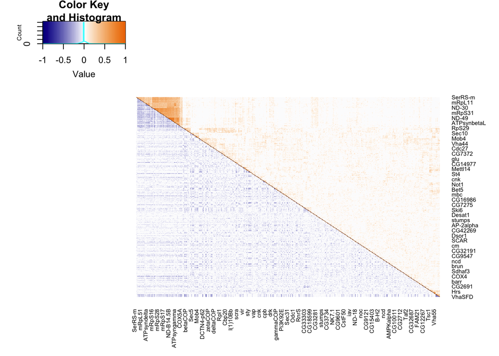

```r
common_matrix_clustered_human_matrix <- data.matrix(common_matrix_clustered_human)

heatmap.2(common_matrix_clustered_human_matrix,
          Rowv = FALSE,
          Colv = FALSE,
          col = c((colorRampPalette(c("darkblue", "white", "darkorange2"))(100))),
          trace = "none",
          dendrogram = "none",
          na.color = "darkorange4")
```

## 19. Interactive heatmap of hierarchical clustered matrix (clustering based on human gene effect correlation), including genegroup annotations

```r
# Replace NA values by -1.01 (to make diagonal be plotted in dark blue, instead of white)
common_matrix_clustered_human_matrix[is.na(common_matrix_clustered_human_matrix)] <- -1.01

# Create a label names vector to plot names with genegroup annotation:
labelnames_human <- as_tibble(matrix(nrow = 430, ncol = 1)) %>%
  mutate(V1 = rownames(common_matrix_clustered_human_matrix)) %>%
  rename(Gene_name = V1) %>%
  left_join((orthologues_genegroups_unique %>% select(Gene_name, gene_group)), by = "Gene_name") %>%
  mutate(gene_group = ifelse(is.na(gene_group), "no_ann", gene_group)) %>%
  unite(col = "gene", Gene_name, gene_group, sep = "__")
labelnames_human_vec <- labelnames_human[["gene"]]

# Plot heatmap (with row- and column labels):
#heatmaply(common_matrix_clustered_human_matrix,
#          plot_method = "plotly",
#          colors = c((colorRampPalette(c("darkblue",  "blue3", "white", "darkorange2", "darkorange4"))(50))),
#          limits = c(-1,1),
#          Rowv = FALSE,
#          Colv = FALSE,
#          dendrogram = "none",
#          fontsize_row = 10,
#          fontsize_col = 10,
#          key.title = " Colorkey: \n blue: gen. int. profile fly \n orange: gene effect human",
#          colorbar_len = 0.5,
#          row_text_angle = 0,
#          column_text_angle = -45,
#          main = " Heatmap of pos. pearson correlation values \n Annotated Genes and nearest neighbors, clust: gene effect human",
#          margins = c(30, 30, 70, 30),
#          labRow = labelnames_human_vec,
#          labCol = labelnames_human_vec,
#          file = "/Users/b110/Desktop/VeraPeters/hclustering_cross_organism/hclustering_fly_human_heatmap_clustered_human_withanno.html"
#          )

# Plot heatmap (without row- and column labels):
#heatmaply(common_matrix_clustered_human_matrix,
#          plot_method = "plotly",
#          colors = c((colorRampPalette(c("darkblue",  "blue3", "white", "darkorange2", "darkorange4"))(50))),
#          limits = c(-1,1),
#          Rowv = FALSE,
#          Colv = FALSE,
#          dendrogram = "none",
#          key.title = " Colorkey: \n blue: gen. int. profile fly \n orange: gene effect human",
#          colorbar_len = 0.5,
#          row_text_angle = 0,
#          column_text_angle = -45,
#          main = " Heatmap of pos. pearson correlation values \n Annotated Genes and nearest neighbors, clust: gene effect human",
#          margins = c(30, 30, 70, 30),
#          showticklabels = FALSE,
#          file = "/Users/b110/Desktop/VeraPeters/hclustering_cross_organism/hclustering_fly_human_heatmap_clustered_human_withoutanno.html"
#          )
```